# O2 LRC Fitting

Douglas A. Campbell

##Introduction We use an optode to measure [O2] µmol l-1 in suspensions of phytoplankton. Changes in [O2] reflect (hopefully) oxygen evolution or oxygen consumption by the cell suspension.

## Materials and Methods

This .Rmd Rworkbook imports O2, FRRf and Metadata in .Rds after import through O2Import and a SoliSenseImport, and comparison through a FRRO2Compare

It fits and plots models for JVPSII and O2 light response curves, and reports the parameters of the fits.

# Set Chunk Options

```r
#"..", takes up a level in the directory path
Project <- "FluorO2"

Run <- "SySlBiolSteps"

TC <- "TC"


FileID <- "O2FRRfMeta"

DataIn <- file.path("..", "FitData")
ChlDataIn <- file.path("..","ImportData")
#DataOut <- file.path("..","ImportData", "Optode")



#Set URL for MetaData
#MetaDataURL <- "https://docs.google.com/spreadsheets/d/1ZXpwR7Gfto-uRzVdXzMpQF4frbrvMLH_IyLqonFZRSw/edit#gid=0"
```

# Call libraries to access functions

```r
library(tidyverse)
library(lubridate)
# library(googlesheets4)
# library(googledrive)
library(minpack.lm) #non linear model fitting
library(broom)
```

```r
Wavelengths_nm = c(445, 470, 505, 535, 590)
Colours_nm = c("darkblue", "dodgerblue", "darkgreen", "yellowgreen",  "darkorange")

names(Colours_nm) <- Wavelengths_nm
Colours_nm
```

```
          445           470           505           535           590
   "darkblue"  "dodgerblue"   "darkgreen" "yellowgreen"  "darkorange"
```

This chunk reads in the MetaData catalog from googlesheets

```r
#  gs4_deauth()
# # #deauthorizes access to googlesheet
# #
#  MetaCatalog <- read_sheet(MetaDataURL) %>%
# # # sheet is read in by sheet ID, obtained from the URL of the sheet.
# # # read_sheet has an annoying "feature" to set the type of columns it can't parse to a list.
# # # ggplot/dplyr doesn't like working with a dataframe of lists.
# # # In this case WL is set to a list since some values are numbers, some are strings, some are blank.
# # # To fix this, first drop all rows missing WL, then unlist.
# # # Must first drop NA rows since unlist will collapse NULL lists, then the unlisted WL is a shorter length than original WL column, which mutate doesn't like.
# #
#  drop_na(WL) %>%
#    mutate(WL = unlist(WL))
#
#  as.data.frame(MetaCatalog)
```

```r
O2FRRfMeta <- readRDS(file.path(DataIn, paste(paste(Project, Run, TC, FileID, sep = "_"), ".Rds", sep = "")))

O2FRRfMeta <- O2FRRfMeta %>%
  select(-c("ObsTime", "ObsDateTime", "Time__mSec", "Run.x",  "carQt", "p680Q", "p680Qt", "S/N_raw", "fQB", "PAR_3", "PAR_4", "PAR_5", "PAR_6", "QBP_Size", "Run.y", "Description", "doi", "Inoc_mL", "Media_mL", "ExpCul", "InnocDate", "Source", "SourceSalinity", "Optode", "OptodeCh", "ExpStartTime", "O2lm" ))
```

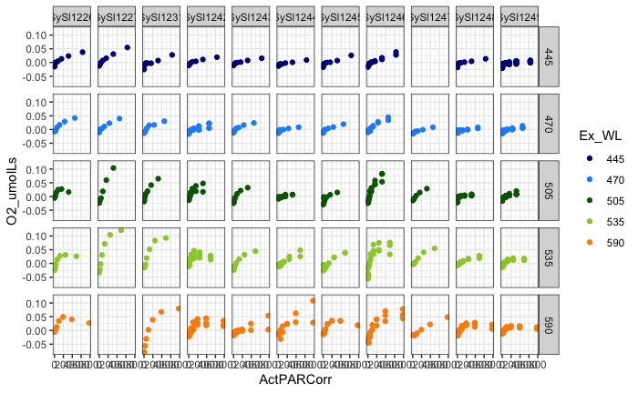

```r
O2FRRfMeta %>%
  ggplot() +
  geom_point(aes(x = ActPARCorr, y = O2_umolLs, colour = Ex_WL)) +
  scale_colour_manual(values = Colours_nm) +
  facet_grid(rows = vars(Ex_WL), cols = vars(CultureID)) +
  theme_bw()
```

```r
Chl <- readRDS(file.path(ChlDataIn, "PICO_ChlTurnerAll.Rds" ))

#collapse to averages
ChlAv <- Chl %>%
  select(-c("Chl_ugL", "Chl_ugmL", "cellsml", "Chla_ugN")) %>%
  unique() %>%
  select(-c("Strain", "InnocDate", "ExpDate", "Par_ue", "Photoperiod" , "Calculated_µmolPhotons_m-2d-1", "Tube", "O2", "WL","LightShape", ))
```

# Merge O2FRRfMeta & Chl Data

```r
O2FRRfMeta <- left_join(x = O2FRRfMeta, y = ChlAv, by = join_by("CultureID", "ObsDate" == "DATE"))
```

# O2 per chl

O2 per cell

```r
O2FRRfMeta <- O2FRRfMeta %>%
  mutate(O2_umolugChls = O2_umolLs/(meanChl_ugmL * 1000),
    O2evln_O2ugChls = O2evln_O2ls/(meanChl_ugmL * 1000),
    O2_umolCells = O2_umolLs/(meancellsml * 1000),
    O2evln_O2Cells = O2evln_O2ls/(meancellsml * 1000))
```

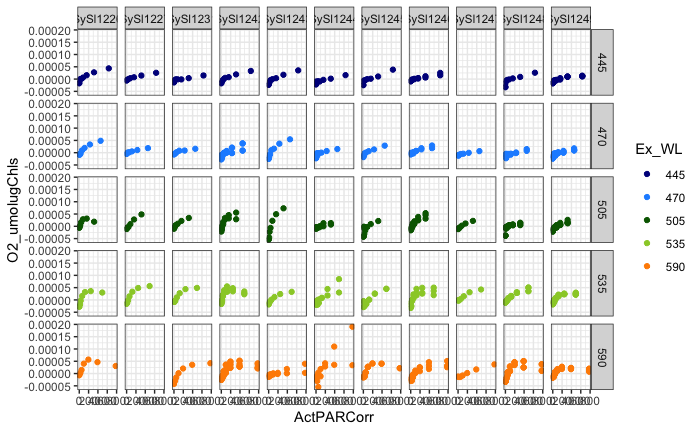

```r
O2FRRfMeta %>%
  ggplot() +
  geom_point(aes(x = ActPARCorr, y = O2_umolugChls, colour = Ex_WL)) +
  scale_colour_manual(values = Colours_nm) +
  facet_grid(rows = vars(Ex_WL), cols = vars(CultureID)) +
  theme_bw()
```

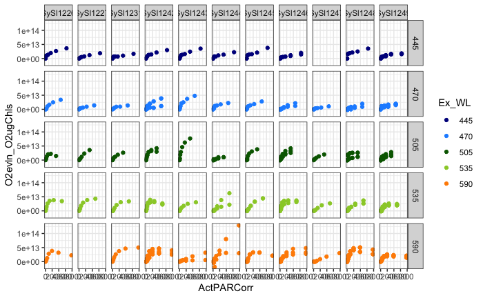

```r
O2FRRfMeta %>%
  ggplot() +
  geom_point(aes(x = ActPARCorr, y = O2evln_O2ugChls, colour = Ex_WL)) +
  scale_colour_manual(values = Colours_nm) +
  facet_grid(rows = vars(Ex_WL), cols = vars(CultureID)) +
  theme_bw()
```

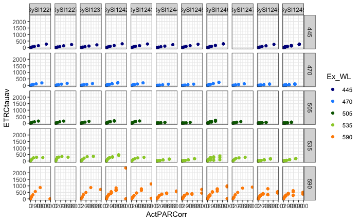

```r
O2FRRfMeta %>%
  ggplot() +
  geom_point(aes(x = ActPARCorr, y = ETRCtauav, colour = Ex_WL)) +
  scale_colour_manual(values = Colours_nm) +
  facet_grid(rows = vars(Ex_WL), cols = vars(CultureID)) +
  theme_bw()
```

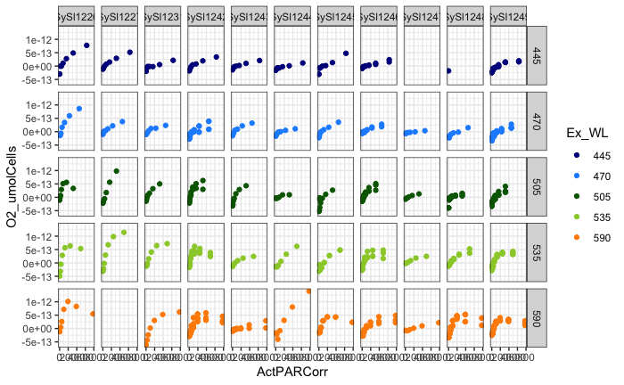

```r
O2FRRfMeta %>%
  ggplot() +
  geom_point(aes(x = ActPARCorr, y =  O2_umolCells, colour = Ex_WL)) +
  scale_colour_manual(values = Colours_nm) +
  facet_grid(rows = vars(Ex_WL), cols = vars(CultureID)) +
  theme_bw()
```

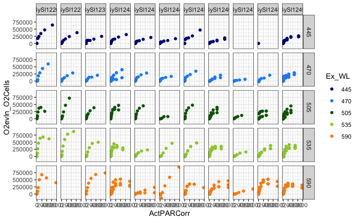

```r
O2FRRfMeta %>%
  ggplot() +
  geom_point(aes(x = ActPARCorr, y = O2evln_O2Cells, colour = Ex_WL)) +
  scale_colour_manual(values = Colours_nm) +
  facet_grid(rows = vars(Ex_WL), cols = vars(CultureID)) +
  theme_bw()
```

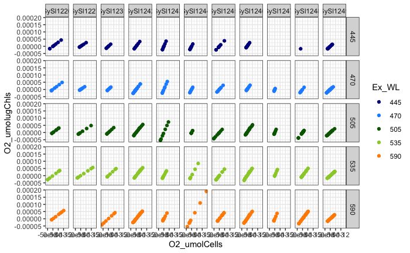

```r
O2FRRfMeta %>%
  ggplot() +
  geom_point(aes(x = O2_umolCells, y = O2_umolugChls, colour = Ex_WL)) +
  scale_colour_manual(values = Colours_nm) +
  facet_grid(rows = vars(Ex_WL), cols = vars(CultureID)) +
  theme_bw()
```

# Define model equations

Citations: Ma X, Liu Q, Zhang Z, Zhang Z, Zhou Z, Jiang Y, et al. (2021) Effects of photosynthetic models on the calculation results of photosynthetic response parameters in young Larix principis- rupprechtii Mayr. plantation. PLoS ONE 16(12): e0261683. https://doi.org/10.1371/journal.pone.0261683

https://www.frontiersin.org/articles/10.3389/fpls.2020.581851/full

I: incident light, umol photons m-2 s-1 a: alpha, initial slope of light response curve under limiting light; the ‘affinity’ of the culture for light. Pmax: maximum rate of photosynthesis; umol O2 chl-1 s-1; the ‘capacity’ of the culture for photosynthesis.

R: dark respiration, umol O2 chl-1 s-1

b: beta ‘photoinhibition’ term for decline in oxygen evolution under increasing incident light. This decrease can result from multiple mechanisms.

g: gamma fitting term related to curvature of response.

d: change in respiration under illumination.

```r
# simple saturating function; rectangular hyperbola

linear <- function(I, m, b){(I*m) + b
  }


lrc <- function(I, a, Pmax, R){((a * I * Pmax)/((a*I) + Pmax)) - R
}

# # function with beta photoinhibition
# lrc_beta <- function(I, a, b, g, R){(a * (((1 - (b*I))/(1 + (g*I)))*I)) - R
# }

# function with beta photoinhibition
lrc_beta <- function(I, a, b, R){(a * (((1 - (b*I)))*I)) - R
}

# function with light-dependent acceleration of Respiration
lrc_dr <- function(I, a, Pmax, R, d){((a * I * Pmax)/((a*I) + Pmax)) - (R + (R * I^2 * d))
}
```

# Fit model equations

```r
alpha_est =  (max(O2FRRfMeta$O2_umolugChls, na.rm = TRUE) - min(O2FRRfMeta$O2_umolugChls, na.rm = TRUE))/(max(O2FRRfMeta$ActPARCorrinter, na.rm = TRUE) - min(O2FRRfMeta$ActPARCorrinter, na.rm = TRUE))


O2Models <- O2FRRfMeta %>%
  filter(!is.na(E_days)) %>%
  filter(E_days %in% c(3,4,5,7)) %>%
  nest(.by = c("Project", "Strain", "Ex_WL", "Par_ue":"Temp_c", "WL", "O2_Category")) %>%
    mutate(Linear_model = map(data, possibly(~lm(O2_umolugChls ~ ActPARCorrinter, data = .)), NULL)
                        ) %>%
    mutate(Linear_Param = map(Linear_model, tidy)
           ) %>%
  mutate(LRC_model = map(data, possibly(~nlsLM(O2_umolugChls ~ lrc(I = ActPARCorrinter, a, Pmax, R),
                               data = .x,
                               start = list(a = alpha_est,
                                            Pmax = max(.$O2_umolugChls, na.rm = TRUE),
                                            R = min(.$O2_umolugChls, na.rm = TRUE)),
                               control = nls.lm.control(maxiter = 100),
                         ), NULL)
                          )
          ) %>%
   mutate(LRC_Param = map(LRC_model, tidy),
          LRC_Predict = map(LRC_model, augment))  %>%
    mutate(LRCdR_model = map(data,possibly(~nlsLM(O2_umolugChls ~ lrc_dr(I = ActPARCorrinter, a, Pmax, R, d),
                               data = .x,
                               start = list(a = alpha_est,
                                            Pmax = max(.$O2_umolugChls, na.rm = TRUE),
                                            R = min(.$O2_umolugChls, na.rm = TRUE),
                                            d = alpha_est/10),
                               control = nls.lm.control(maxiter = 100),
                          ), NULL)
                          )
          )  %>%
     mutate(LRCdR_Param = map(LRCdR_model, tidy),
            LRCdR_Predict = map(LRCdR_model, augment)) %>%
   mutate(LRCbeta_model = map(data, possibly(~nlsLM(O2_umolugChls ~ lrc_beta(I = ActPARCorrinter, a, b, R),
                               data = .x,
                               start = list(a = alpha_est,
                                            b = alpha_est/10,
                                            R = min(.$O2_umolugChls, na.rm = TRUE)),
                               control = nls.lm.control(maxiter = 100),
                          ), NULL)
                          )
          ) %>%
  mutate(LRCbeta_Param = map(LRCbeta_model, tidy),
          LRCbeta_Predict = map(LRCbeta_model, augment))
```

# Plot models

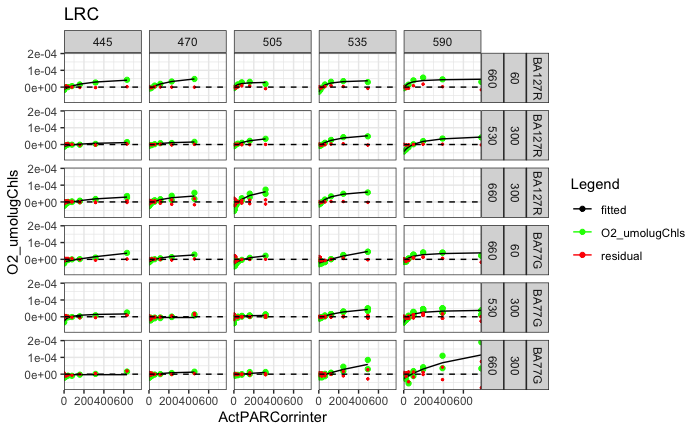

```r
# Adding legend for lines
#https://community.rstudio.com/t/adding-manual-legend-to-ggplot2/41651/2

line_colours = c("O2_umolugChls" = "green",
            "fitted" = "black",
            "residual" = "red")

O2Models %>%
  unnest(LRC_Predict) %>%
  ggplot(aes(x = ActPARCorrinter)) +
  geom_point(aes(y = O2_umolugChls, colour =  "O2_umolugChls")) +
  geom_line(aes(y = `.fitted`, colour = "fitted")) +
  geom_point(aes(y = `.resid`, colour = "residual"), size = 0.5) +
  geom_hline(yintercept = 0, linetype = "dashed") +
  labs(colour = "Legend", title = "LRC") +
  scale_colour_manual(values = line_colours) +
  scale_x_continuous(expand = c(0,0)) +
  facet_grid(cols = vars(Ex_WL), rows = vars(Strain, Par_ue, WL)) +
  theme_bw()
```

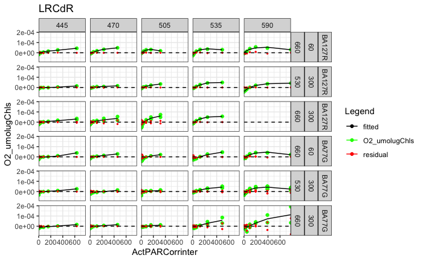

```r
 O2Models %>%
  unnest(LRCdR_Predict) %>%
  ggplot(aes(x = ActPARCorrinter)) +
  geom_point(aes(y = O2_umolugChls, colour =  "O2_umolugChls")) +
  geom_line(aes(y = `.fitted`, colour = "fitted")) +
  geom_point(aes(y = `.resid`, colour = "residual"), size = 0.5) +
  geom_hline(yintercept = 0, linetype = "dashed") +
  labs(colour = "Legend", title = "LRCdR") +
  scale_colour_manual(values = line_colours) +
  scale_x_continuous(expand = c(0,0)) +
  facet_grid(cols = vars(Ex_WL), rows = vars(Strain, Par_ue, WL)) +
  theme_bw()
```

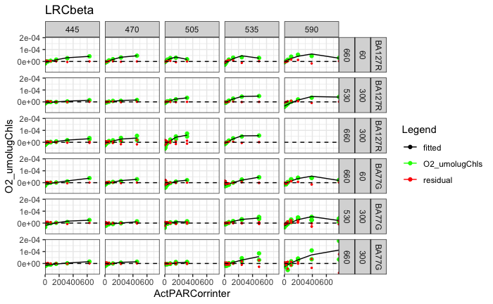

```r
 O2Models %>%
  unnest(LRCbeta_Predict) %>%
  ggplot(aes(x = ActPARCorrinter)) +
  geom_point(aes(y = O2_umolugChls, colour =  "O2_umolugChls")) +
  geom_line(aes(y = `.fitted`, colour = "fitted")) +
  geom_point(aes(y = `.resid`, colour = "residual"), size = 0.5) +
  geom_hline(yintercept = 0, linetype = "dashed") +
  labs(colour = "Legend", title = "LRCbeta") +
  scale_colour_manual(values = line_colours) +
  scale_x_continuous(expand = c(0,0)) +
  facet_grid(cols = vars(Ex_WL), rows = vars(Strain, Par_ue, WL)) +
  theme_bw()
```

```r
NA
NA
NA
```

# Report model parameters

Failing to report outputs from different model fits; rework. ## LRC model parameters

```r
# simple saturating function; rectangular hyperbola
# lrc <- function(I, a, Pmax, R){((a * I * Pmax)/((a*I) + Pmax)) - R
# }

LRC_Param <- O2Models %>%
  unnest(LRC_Param) %>%
  select(c(term, estimate, std.error)) %>%
  mutate(Model = "lrc", .before = "term")

LRC_O2compEst <- lrc(I = seq(0,100, by = 1), a = LRC_Param$estimate[LRC_Param$term == "a"], Pmax = LRC_Param$estimate[LRC_Param$term == "Pmax"], R = LRC_Param$estimate[LRC_Param$term == "R"])
O2compEst <- which(abs(LRC_O2compEst - 0) == min(abs(LRC_O2compEst - 0)))

LRC_Param <- LRC_Param %>%
  mutate(O2comp = O2compEst)

#poor coding, hack fix
LRC_Param2 <- tibble(Model = "lrc",
                     Value = colnames(LRC_Param)[3:4],
                     a = c(as.numeric(LRC_Param$estimate[1]), as.numeric(LRC_Param$std.error[1])),
                     Pmax = c(as.numeric(LRC_Param$estimate[2]), as.numeric(LRC_Param$std.error[2])),
                     R = c(as.numeric(LRC_Param$estimate[3]), as.numeric(LRC_Param$std.error[3]))) %>%
  mutate(Pmax_R = Pmax - R,
         O2Comp = c(O2compEst, NA))

LRC_Param2
```

| Model | Value | a | Pmax | R | Pmax_R | O2Comp |
| --- | --- | --- | --- | --- | --- | --- |
| lrc | estimate | 1.833088e-07 | 6.401264e-05 | 1.225046e-05 | 5.176218e-05 | 74 |
| lrc | std.error | 7.271052e-08 | 1.730049e-05 | 2.643647e-06 | 1.465685e-05 | NA |

```r
NA
```

## LRCbeta_model_parameters

Simplified eqn need to reestimate Pmax and Ek

```r
# function with beta photoinhibition
# lrc_beta <- function(I, a, b, g, R){(a * (((1 - (b*I))/(1 + (g*I)))*I)) - R
# }

LRCbeta_Param <- O2Models %>%
  unnest(LRCbeta_Param) %>%
  select(c(term, estimate, std.error)) %>%
  mutate(Model = "lrcbeta", .before = "term")

LRCbeta_O2compEst <- lrc_beta(I = seq(0,100, by = 1), a = LRCbeta_Param$estimate[LRCbeta_Param$term == "a"], b = LRCbeta_Param$estimate[LRCbeta_Param$term == "b"], R = LRCbeta_Param$estimate[LRCbeta_Param$term == "R"])
O2compEst_beta <- which(abs(LRCbeta_O2compEst - 0) == min(abs(LRCbeta_O2compEst - 0)))

LRCbeta_Param <- LRCbeta_Param %>%
  mutate(O2comp = O2compEst_beta)

LRCbeta_Param2 <- tibble(Model = "lrc_beta",
                         Value = colnames(LRCbeta_Param)[3:4],
                     a = c(as.numeric(LRCbeta_Param$estimate[1]), as.numeric(LRCbeta_Param$std.error[1])),
                     b = c(as.numeric(LRCbeta_Param$estimate[2]), as.numeric(LRCbeta_Param$std.error[2])),
                     R = c(as.numeric(LRCbeta_Param$estimate[4]), as.numeric(LRCbeta_Param$std.error[3]))) %>%
  mutate(Pmax = a*((sqrt(b) - sqrt(b)))^2,
         Pmax_R = Pmax - R,
         EK = Pmax/a,
        O2Comp = c(O2compEst_beta, NA))

LRCbeta_Param2
```

| Model | Value | a | b | R | Pmax | Pmax_R | EK | O2Comp |
| --- | --- | --- | --- | --- | --- | --- | --- | --- |
| lrc_beta | estimate | 1.202559e-07 | 0.0007319544 | 2.311225e-07 | 0 | -2.311225e-07 | 0 | 76 |
| lrc_beta | std.error | 2.905595e-08 | 0.0002179594 | 2.405931e-06 | 0 | -2.405931e-06 | 0 | NA |

## LRCdR_model_parameters

```r
# function with light-dependent acceleration of Respiration
#lrc_dr <- function(I, a, Pmax, R, d){((a * I * Pmax)/((a*I) + Pmax)) - (R + (R * I * d))
#}

LRCdR_Param <- O2Models %>%
  unnest(LRCdR_Param) %>%
  select(c(term, estimate, std.error)) %>%
  mutate(Model = "lrc_dR", .before = "term")

LRCdR_O2compEst <- lrc_dr(I = seq(0,100, by = 1), a = LRCdR_Param$estimate[LRCdR_Param$term == "a"], Pmax = LRCdR_Param$estimate[LRCdR_Param$term == "Pmax"], d = LRCdR_Param$estimate[LRCdR_Param$term == "d"], R = LRCdR_Param$estimate[LRCdR_Param$term == "R"])
O2compEst_dR <- which(abs(LRCdR_O2compEst - 0) == min(abs(LRCdR_O2compEst - 0)))

LRCdR_Param <- LRCdR_Param %>%
  mutate(O2comp = O2compEst_dR)

LRCdR_Param2 <- tibble(Model = "lrc_dR",
                    Value = colnames(LRCdR_Param)[3:4],
                     a = c(as.numeric(LRCdR_Param$estimate[1]), as.numeric(LRCdR_Param$std.error[2])),
                     Pmax = c(as.numeric(LRCdR_Param$estimate[2]), as.numeric(LRCdR_Param$std.error[2])),
                     R = c(as.numeric(LRCdR_Param$estimate[3]), as.numeric(LRCdR_Param$std.error[3])),
                     d = c(as.numeric(LRCdR_Param$estimate[4]), as.numeric(LRCdR_Param$std.error[4]))) %>%
  mutate(Pmax_R = Pmax - R,
         EK = Pmax/a,
        O2Comp = c(O2compEst_dR, NA))

LRCdR_Param2
```

| Model | Value | a | Pmax | R | d | Pmax_R | EK | O2Comp |
| --- | --- | --- | --- | --- | --- | --- | --- | --- |
| lrc_dR | estimate | 4.277158e-07 | 2.887985e-05 | 1.405663e-05 | -3.322513e-06 | 1.482322e-05 | 67.52112 | 76 |
| lrc_dR | std.error | 1.009078e-05 | 1.009078e-05 | 2.985305e-06 | 1.680533e-06 | 7.105470e-06 | 1.00000 | NA |

# Plots showing fit parameters

## LRCbeta model with ‘photoinhibition’ of O2 evolution under increasing light.

```r
LRCbeta_param_colours = line_colours = c("umolO2_mmolChl1_s1" = "green",
                                 "alpha" = "green",
                                 "fitted" = "black",
                                 "resid" = "red",
                                 "beta" = "orange",
                                 "Ek" = "blue",
                                 "Respiration" = "darkred",
                                 "Pmax" = "darkgreen",
                                 "O2Comp" = "red",
                                 "dR" = "darkred")

a_fun <- function(I, a = as.numeric(LRCbeta_Param2$a[1]), R = as.numeric(LRCbeta_Param2$R[1])){(I * a) - R
}

b_fun <- function(I, b = as.numeric(LRCbeta_Param2$b[1]), g = as.numeric(LRCbeta_Param2$g[1]), R = as.numeric(LRCbeta_Param2$R[1])){(I * (1-(b*I))/(1 + (g*I))) - R
}

r_fun <- function(R = as.numeric(LRCdR_Param2$R[1]), I, d){R + (R * I * d)
  }


O2Models %>%
  unnest(LRCbeta_Predict) %>%
  mutate(R = LRCbeta_Param2$R[1],
         PMax_R = LRCbeta_Param2$Pmax_R[1],
         Ek = LRCbeta_Param2$EK[1],
         O2Comp = LRCbeta_Param2$O2Comp[1],
         alpha = a_fun(I = umolphotons_m2_s1, a = as.numeric(LRCbeta_Param2$a[1])),
         beta = b_fun(I = umolphotons_m2_s1, b = as.numeric(LRCbeta_Param2$b[1]), g = as.numeric(LRCbeta_Param2$g[1]), R = R),
         dR = r_fun(I = umolphotons_m2_s1, d = 0.001)) %>%
  ggplot(aes(x = umolphotons_m2_s1)) +
  xlim(0, max(as.numeric(O2Data$umolphotons_m2_s1) + 20, na.rm = TRUE)) +
  ylim(min(as.numeric(O2Data$umolO2_mmolChl1_s1), na.rm = TRUE) - 20, max(as.numeric(O2Data$umolO2_mmolChl1_s1) + 20, na.rm = TRUE)) +
  geom_point(aes(y = umolO2_mmolChl1_s1, colour =  "umolO2_mmolChl1_s1")) +
  geom_line(aes(y = `.fitted`, colour = "fitted")) +
  geom_hline(yintercept = 0, linetype = "dashed") +
  geom_line(aes(y = -R, colour = "Respiration")) +
  geom_line(aes(y = PMax_R, colour = "Pmax")) +
  geom_line(aes(y = alpha, colour = "alpha")) +
  geom_line(aes(y = beta, colour = "beta"), linetype = "dotted") +
  geom_line(aes(x = Ek, y = umolO2_mmolChl1_s1, colour = "Ek")) +
  geom_line(aes(x = O2Comp, y = umolO2_mmolChl1_s1, colour = "O2Comp")) +
  labs(title = "LRCbeta", subtitle = Operator, colour = "Legend") +
  scale_colour_manual(values = LRCbeta_param_colours) +
  scale_x_continuous(expand = c(0,0)) +
  theme_bw()
```

[output not shown]

## LRCdR model with acceleration of respiration under increasing light.

```r
# function with light-dependent acceleration of Respiration
# lrc_dr <- function(I, a, Pmax, R, d){((a * I * Pmax)/((a*I) + Pmax)) - (R + (R * I^2 * d))
# }

LRCdR_param_colours = line_colours = c("umolO2_mmolChl1_s1" = "green",
                                 "alpha" = "green",
                                 "fitted" = "black",
                                 "Ek" = "blue",
                                 "Pmax" = "darkgreen",
                                 "O2Comp" = "red",
                                 "dR" = "darkred")

a_fun <- function(I, a = as.numeric(LRCbeta_Param2$a[1]), R = as.numeric(LRCbeta_Param2$R[1])){(I * a) - R
}

r_fun <- function(R = as.numeric(LRCdR_Param2$R[1]), I, d){R + (R * I^2 * d)
}


O2Models %>%
  unnest(LRCdR_Predict) %>%
  mutate(R = LRCdR_Param2$R[1],
         PMax_R = LRCdR_Param2$Pmax_R[1],
         Ek = LRCdR_Param2$EK[1],
         O2Comp = LRCdR_Param2$O2Comp[1],
         alpha = a_fun(I = umolphotons_m2_s1, a = as.numeric(LRCdR_Param2$a[1])),
         dR = r_fun(I = umolphotons_m2_s1, d = as.numeric(LRCdR_Param2$d[1]))) %>%
  ggplot(aes(x = umolphotons_m2_s1)) +
  # xlim(0, max(as.numeric(O2Data$umolphotons_m2_s1), na.rm = TRUE)) +
  # ylim(min(as.numeric(O2Data$umolO2_mmolChl1_s1) * 2, na.rm = TRUE) - 20, max(as.numeric(O2Data$umolO2_mmolChl1_s1) *2, na.rm = TRUE)) +
  geom_point(aes(y = umolO2_mmolChl1_s1, colour =  "umolO2_mmolChl1_s1")) +
  geom_line(aes(y = `.fitted`, colour = "fitted")) +
  geom_hline(yintercept = 0, linetype = "dashed") +
  geom_line(aes(y = PMax_R, colour = "Pmax")) +
  geom_line(aes(y = alpha, colour = "alpha")) +
  geom_line(aes(y = -dR, colour = "dR"), linetype = "dashed") +
  geom_line(aes(x = Ek, y = umolO2_mmolChl1_s1, colour = "Ek")) +
  geom_line(aes(x = O2Comp, y = umolO2_mmolChl1_s1, colour = "O2Comp")) +
  labs(title = "LRCdR", subtitle = Operator, colour = "Legend") +
  scale_colour_manual(values = LRCdR_param_colours) +
  scale_x_continuous(expand = c(0,0)) +
  theme_bw()
```

[output not shown]